## Introduction

Interpretation of multi-omics data is very challenging. The IntLIM package aims to integrate multiple types of omics data. Unlike other approaches, IntLIM is focused on understanding how specific multi-omic associations are affected by phenotypic features. To this end, we develop a linear modeling approach that describes how multi-omic associations are affected by phenotype. More information can be found on [our publication “IntLIM: integration using linear models of metabolomics and gene expression data”](https://bmcbioinformatics.biomedcentral.com/articles/10.1186/s12859-018-2085-6)The workflow involves the following steps: 1) Input multi-omic data files. 2) Filter data sets by analyte abundance and imputed values. 3) Run the linear model to extract pairwise interaction significance. 4) Filter results by p-values and/or Spearman correlation differences, interaction coefficient percentiles, and r-squared values. 5) plot/visualize specific analyte associations.

## Installation

IntLIM is an R package and can be run on version >= 3.2.0.

Download (or upgrade) R here: https://cloud.r-project.org/

RStudio (an interface to R than can make R easier to use) can be download here (not required): https://www.rstudio.com/products/rstudio/download3/

The function install_github() from the “devtools” package (Wickham and Chang, 2015) installs IntLIM directly from GitHub. To install IntLIM, enter the following:

```r
if(!require("devtools")){
  install.packages("devtools")
}
library("devtools")
install_github("ncats/IntLIM@liz_dev")
```

IntLIM can be loaded using the library function

```r
library(IntLIM)
```

## Inputting Analyte Level Data

The first step is importing in the multi-omic data. To this end we have provided a sample data file for users wishing to use IntLIM.

IntLIM requires a specific format for multi-omic data. For IntLIM, we require the data corresponding to two analyte types, optional metadata for each of these types, and sample meta data. We also need a CSV meta-file that lists the location of the other files. These need to be in the same folder. The formats are described below.  
In addition, we provide a sample set of files.

**Please be sure that all files noted in the CSV file, including the CSV file,** **are in the same folder. Do not include path names in the filenames.**

Users need to input a CSV file with two required columns: ‘type’ and ‘filenames’.

The CSV file is expected to have the following 2 columns and 6 rows:

1. type,filenames
2. analyteType1,myfilename (optional if analyteType2 is provided)
3. analyteType2,myfilename (optional if analyteType1 is provided)
4. analyteType1MetaData,myfilename (optional)
5. analyteType2MetaData,myfilename (optional)
6. sampleMetaData,myfilename"

The data and meta-data is stored in a series of comma-separated-values (.CSV) files.  
The 5 files consist of data for two analyte types, metadata for two analyte types, and sample meta data. A meta-file lists the location of the other 5 files.  
This meta-file is input into IntLIM.

**Please be sure to normalize your data appropriately before inputting it into IntLIM.**

Input data files should be in a specific format:

| File type | Description |
| --- | --- |
| analyteType1 | rows are analytes from type 1 (e.g. metabolites), columns are samples |
| analytetype2 | rows are analytes from type 2 (e.g. genes), columns are samples |
| analyteType1MetaData | rows are analytes, features are columns |
| analyteType2MetaData | rows are analytes, features are columns |
| sampleMetaData | rows are samples, features are columns |

For the sampleMetaData, the first column of the sampleMetaData file is assumed to be the sample ID, and those sample IDs should match the first row of analyte data (e.g. it is required that all sample IDs in the analyte data are also in the sampleMetaDatafile).

Additionally, the analyte data files and SampleMetaData need to contain an ‘id’ column that contains the name of the features (analytes) or sample (sample id, name, etc).

A small data set is embedded in a package. This consists of the National Cancer Institute-60 (NCI-60) cell line data with a reduced number of genes for faster calculation. To access it use the following commands. csvfile describes the location of the meta-file describing the location of the other 5 input files.

```r
dir <- system.file("extdata", package="IntLIM", mustWork=TRUE)
csvfile <- file.path(dir, "NCItestinput.csv")
csvfile
```

```
## [1] "H:/R/R-4.1.0/library/IntLIM/extdata/NCItestinput.csv"
```

Through the **ReadData()** function, users input the above .csv files containing analyte data and metadata. **Note: It is assumed that all data has been pre-scaled and preprocessed** The input data, sample data, and metadata are read into an IntLimData object, which will be used for all further analysis.

```r
inputData <- IntLIM::ReadData(inputFile = csvfile,analyteType1id='id',analyteType2id='id',
                              class.feat = list(panelnbr = "factor",
                                                 cellnbr = "numeric",
                                                 PBO_vs_Leukemia = "factor",
                                                drugscore = "numeric"))
```

```
## [1] "IntLIMData created"
```

The **ShowStats()** function allows the user to summarize the data (how many total analytes of each types and samples in each data-set as well as samples in common).  
We have a data-set that consists of 20 cell lines (samples), 1448 genes, and 257 metabolites.

```r
IntLIM::ShowStats(IntLimObject = inputData)
```

```
##   Num_Analytes_Type1 Num_Analytes_Type2 Num_Samples
## 1                257               1448          20
```

## Filtering and Observing Data

Optionally, the **FilterData()** function allows the user to filter out the features (analytes) based on their mean values. Users should input a percentile cutoff and any feature with a mean value below that cutoff will be removed.  
Furthermore we can filter out analytes by percentage of missing or imputed values.  
For the analysis, we filter out the genes with the lowest 10% of gene expression and metabolites with more than 80% imputed values. This is done as below. We henceforth have 1303 genes and 212 metabolites for 20 cell line samples.  
The “stype” variable is the phenotype or outcome of interest. This function checks that the “stype” values are the same for all input data and retains the phenotype data for later use. The optional “class.covar” variable coerces covariates to the given classes.

```r
inputDatafilt <- IntLIM::FilterData(inputData,
                                    analyteType1perc = 0.10, analyteType2perc = 0.10,
                                    analyteMiss = 0.80)
```

The **PlotDistribution()** function allows users to produce a boxplot of the distribution of analyte level data. This is done as below.

```r
IntLIM::PlotDistributions(inputData = inputDatafilt)
```

[interactive chart not shown]

Prior to running the model, the user can also perform a principal component analysis of the analyte data using the **PlotPCA()** function. The **stype** command allows the user to select a column from the sample meta data that color-codes the samples into two categories (two cancer types, tumor vs. non-tumor, etc). For the sample set, we select PBO (prostate/breast/ovarian cancers) vs. the leukemia group.

```r
IntLIM::PlotPCA(inputData = inputDatafilt,stype = "PBO_vs_Leukemia")
```

[interactive chart not shown]

## Run IntLIM

The linear models are run by the **RunIntLim()** function. The **stype** command allows the user to select a column from the sample meta data for the two categories to be compared (two cancer types, tumor vs. non-tumor, etc). Currently, IntLIM supports continuous data and comparison of two categories (**“PBO_vs_Leukemia”** is selected). The resulting object from the analysis is an IntLimResults object containing slotsfor un-adjusted and False Discovery Rate (FDR)-adjusted p-values for the “(g:p)” interaction coefficient. A significant FDR-adjusted p-value implies that the slope of gene-metabolite association in one phenotype is different from the other. The **RunIntLim()** function is based heavily on the MultiLinearModel functions developed for the ClassComparison package part of oompa (http://oompa.r-forge.r-project.org).

```r
myres.gm <- IntLIM::RunIntLim(inputData = inputDatafilt,stype="PBO_vs_Leukemia",
                              covar = c("cellnbr"), outcome = 1,
                              independent.var.type = 2,
                              save.covar.pvals = TRUE)
```

```
## [1] "Running the analysis on"
##
## Leukemia      PBO
##        6       14
## [1] "10 % complete"
## [1] "20 % complete"
## [1] "30 % complete"
## [1] "40 % complete"
## [1] "50 % complete"
## [1] "60 % complete"
## [1] "70 % complete"
## [1] "80 % complete"
## [1] "90 % complete"
## [1] "100 % complete"
##    user  system elapsed
##   10.40    0.11   11.70
```

The **DistPValues()** function allows the user to observe a histogram of the p-values. By default, FDR-adjusted p-values are shown. However, users can also choose to plot nominal p-values.

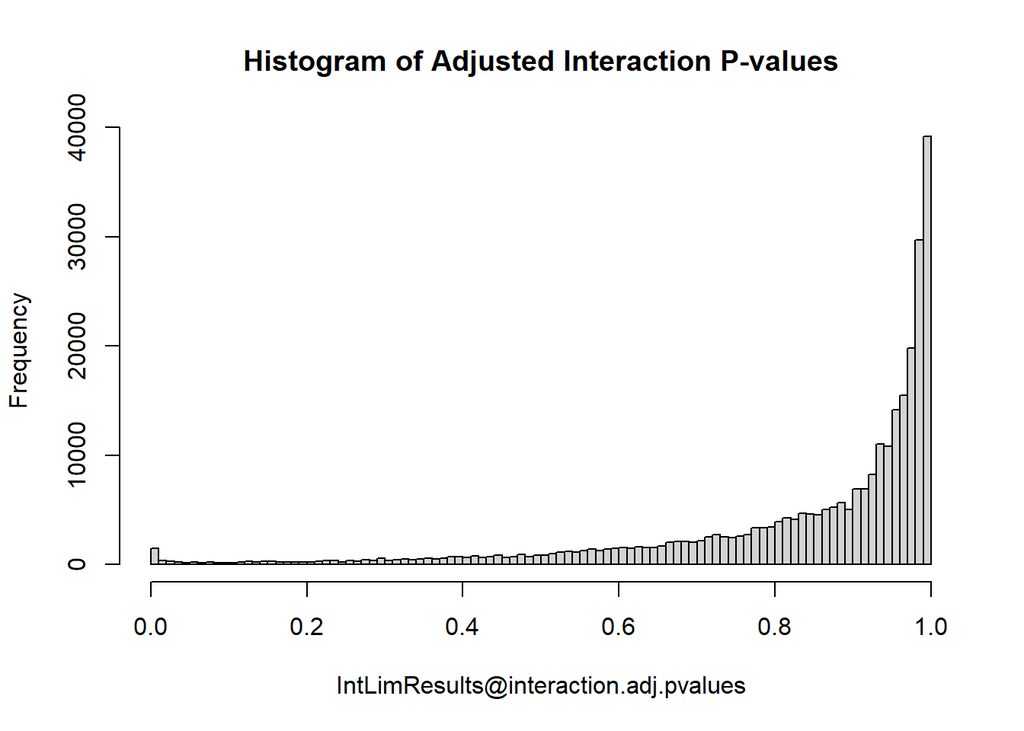

```r
IntLIM::DistPvalues(IntLimResults = myres.gm)
```

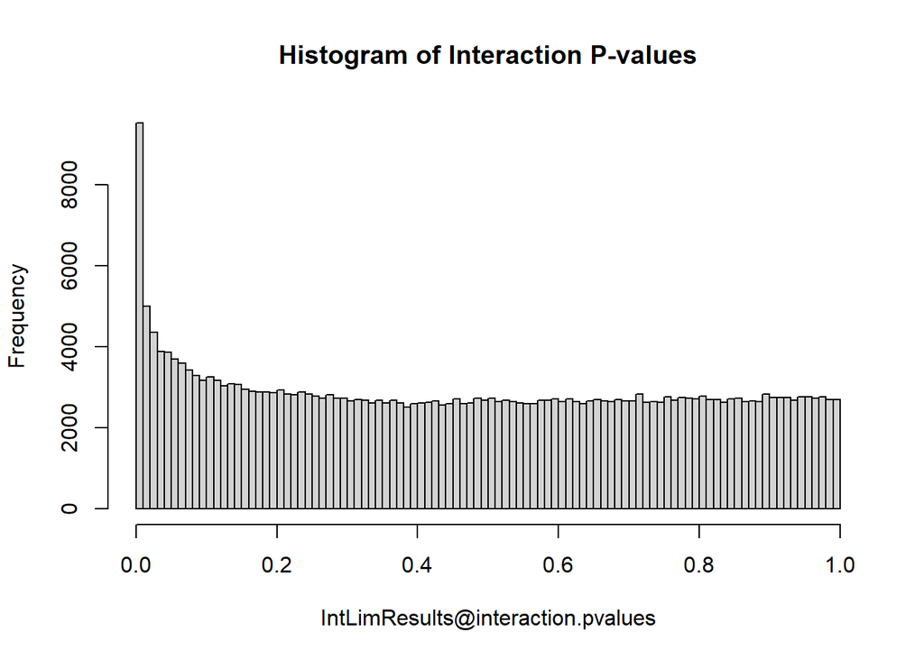

```r
IntLIM::DistPvalues(IntLimResults = myres.gm, adjusted = FALSE)
```

The **DistRSquared()** function allows the user to observe a histogram of the r-squared values.

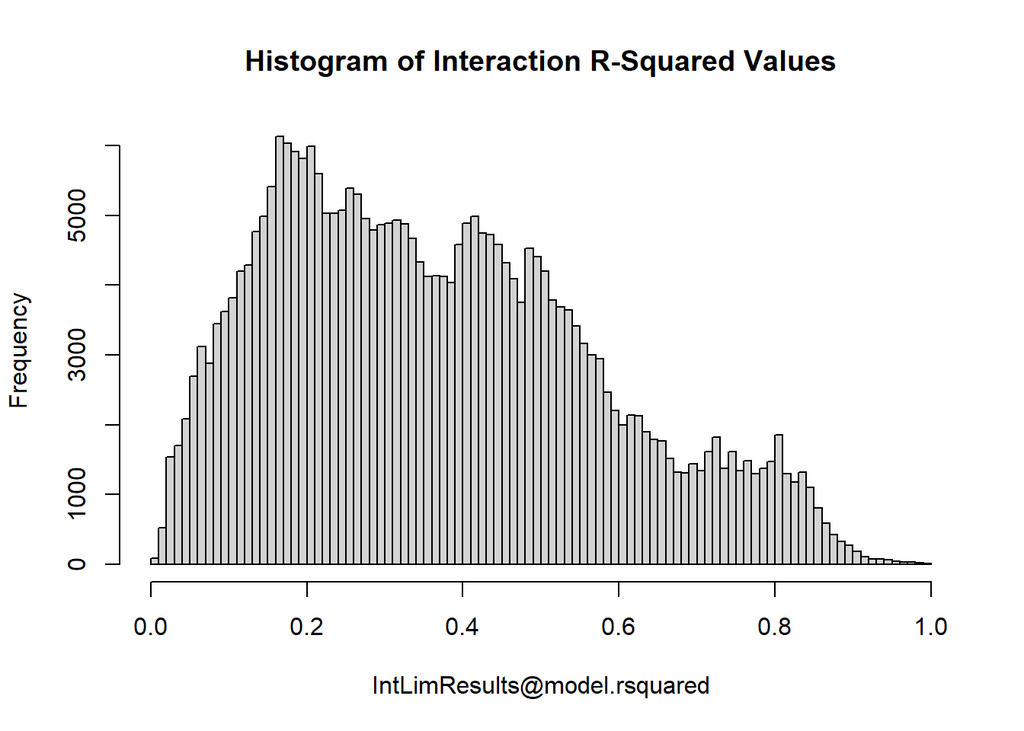

```r
IntLIM::DistRSquared(IntLimResults = myres.gm)
```

The **PValueBoxPlots()** function allows the user to observe the p-value distributions of all covariates in the linear models prior to adjustment. Note: To view these values, you must set **save.covar.pvals** to **TRUE** when running **RunIntLim**.

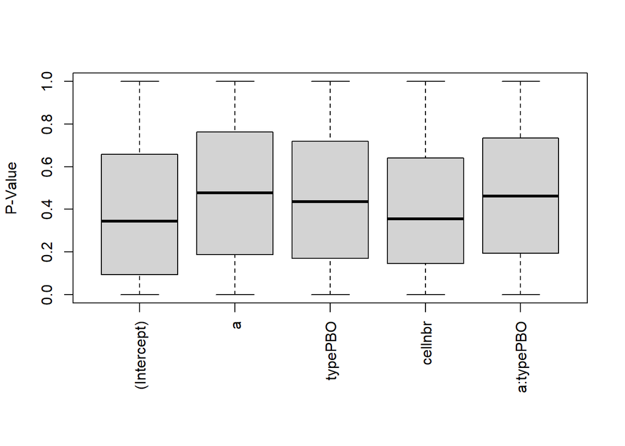

```r
IntLIM::PValueBoxPlots(IntLimResults = myres.gm)
```

The **InteractionCoefficientGraph()** function allows the user to observe the interaction coefficients of all models, sorted in ascending order.

[figure not shown]

```r
IntLIM::InteractionCoefficientGraph(inputResults = myres.gm,
                                    interactionCoeffPercentile = 0.9)
```

The **PlotPair()** function allows the user to plot a chosen analyte association for selected groups. An example is shown below for DLG4 vs. (p-Hydroxyphenyl)lactic acid.

Plot a pair of interest:

```r
IntLIM::PlotPair(inputData = inputDatafilt,
                 inputResults = myres.gm,
                 outcome = 1,
                 independentVariable = 2,
                 outcomeAnalyteOfInterest = "(p-Hydroxyphenyl)lactic acid",
                 independentAnalyteOfInterest = "DLG4")
```

[interactive chart not shown]

The **pvalCoefVolcano()** function allows users to observe a volcano plot comparing the interaction coefficient to the –log10(FDR-adjusted p-value).

```r
IntLIM::pvalCoefVolcano(inputResults = myres.gm, inputData = inputDatafilt,
                        pvalcutoff = 0.05)
```

```
## [1] "289266 pairs found given cutoffs"
```

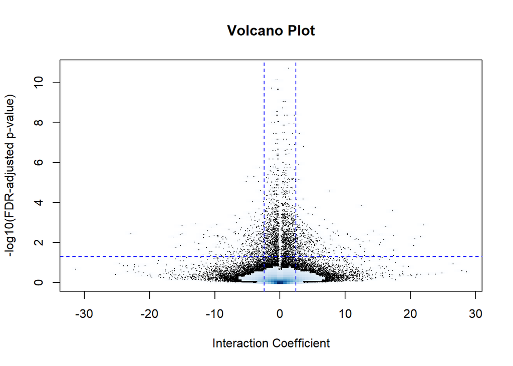

## Filter Results

The **ProcessResults()** function allows the user to filter the results by FDR p-values (default set at 0.05) between the two groups. The output is a list of significant analyte pairs.

```r
myres.gm.sig <- IntLIM::ProcessResults(inputResults = myres.gm,
                                       inputData = inputDatafilt,
                                       pvalcutoff = 0.10, rsquaredCutoff = 0.2,
                                       interactionCoeffPercentile = 0.5)
```

```
## [1] "2908 pairs found given cutoffs"
```

The **InteractionCoefficientGraph()** function allows the user to observe the interaction coefficients of all models, sorted in ascending order.

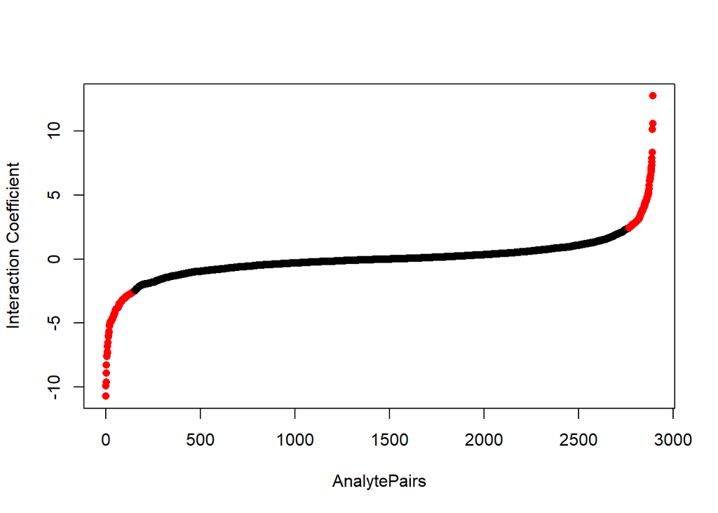

```r
IntLIM::InteractionCoefficientGraph(inputResults = myres.gm,
                                    interactionCoeffPercentile = 0.9)
```

The **HistogramPairs()** function plots the count of analyte pairs by either outcome or independent variable analyte.

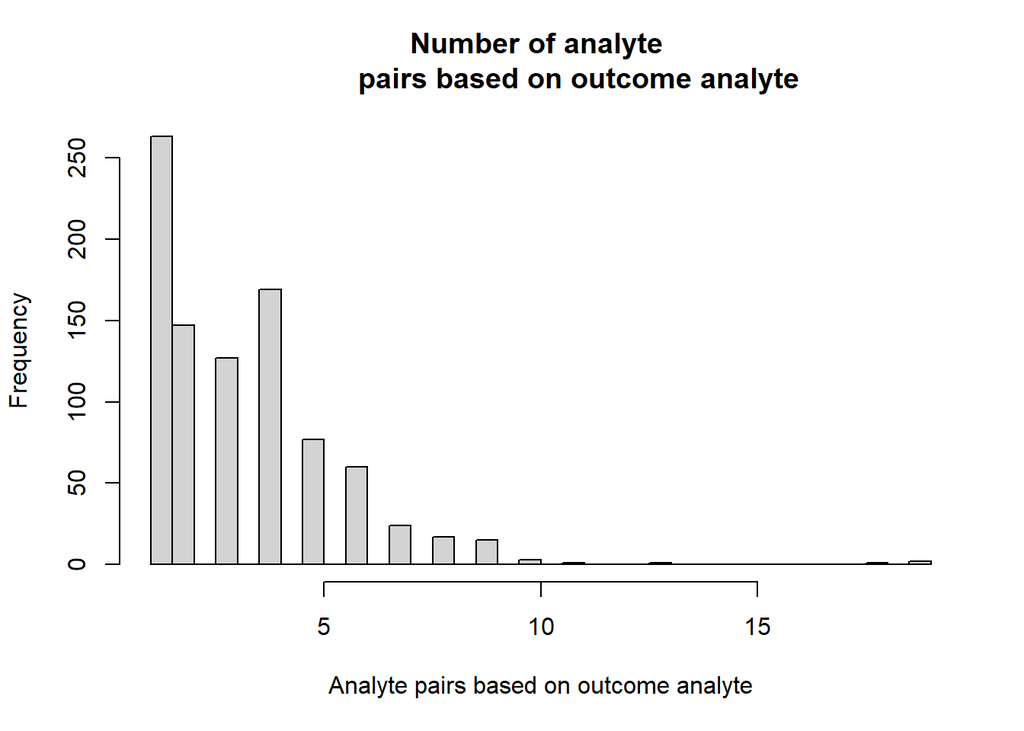

```r
IntLIM::HistogramPairs(myres.gm.sig, type = "outcome")
```

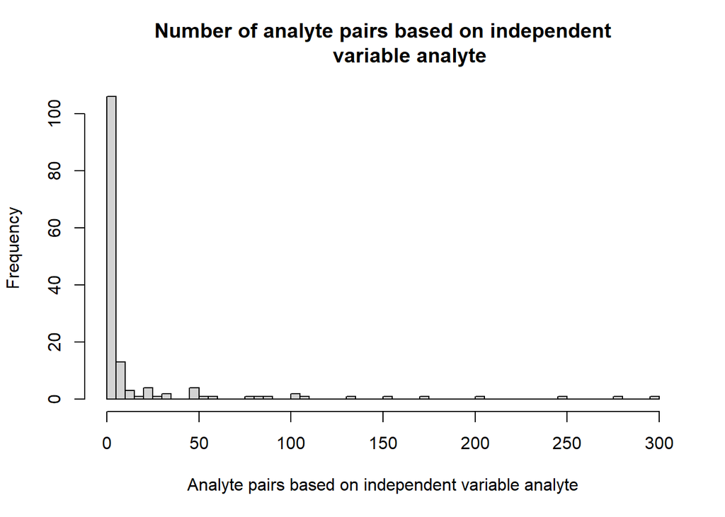

```r
IntLIM::HistogramPairs(myres.gm.sig, type = "independent")
```

Of note, plots are generated using Highcharter (http://jkunst.com/highcharter/) and Plotly (Sievert, et al.) (https://plot.ly), which enables interactive visualization, allowing users to promptly assess the effect of changing parameters on analysis results and accelerating discovery of phenotype-specific analyte pairs. This will greatly allow the workflow to be accessible to non-computational biologists.

The **OutputData()** and **OutputResults()** function allows the users to output the data and results of the analyses into zipped CSV files.

Lastly, various writing functions are implemented. The **OutputData()** and **OutputResults()** function allows the users to output the data and results of the analyses into zipped CSV files.

```r
IntLIM::OutputData(inputData=inputDatafilt,filename=paste(result_dir, "FilteredData.zip", sep = "\\"))
IntLIM::OutputResults(inputResults=myres.gm.sig,filename=paste(result_dir, "MyResults.gm.csv", sep = "\\"))
```

## Run Cross-Validation

You can also choose to run end-to-end cross-validation. This combines the steps of reading, filtering, running IntLIM, and processing the results for multiple folds. **PlotFoldOverlapUpSet** creates an UpSet plot of the significant pairs within each fold and common between folds.

```r
crossValResults <- RunCrossValidation(inputData = inputData, analyteType1perc = 0.10,
                   analyteType2perc = 0.10, analyteMiss = 0.80,
                   stype="PBO_vs_Leukemia", covar = c("cellnbr"), outcome = c(1),
                   independent.var.type = c(2), save.covar.pvals = TRUE,
                   pvalcutoff = 0.10, rsquaredCutoff = 0.2, interactionCoeffPercentile = 0.5
                   folds = 4)
IntLIM::PlotFoldOverlapUpSet(crossValResults$processed)
```

## Run Permutation

You can also choose to run end-to-end permutation. This combines the steps of permuting, running IntLIM, and processing results for multiple permutations. **PermutationSummary** returns a summary of the permutation results and (optionally) a violin plot of the number of significant pairs and analytes.

```r
perm.res <- IntLIM::PermuteIntLIM(data = inputDatafilt, stype = "PBO_vs_Leukemia", outcome = 1,
                      independent.var.type = 2, pvalcutoff = 0.10, interactionCoeffPercentile = 0.5,
                   rsquaredCutoff = 0.2, covar = c("cellnbr"),
                   num.permutations = 5, continuous = TRUE)
summary <- PermutationSummary(permResults = perm.res, inputResults = myres.sig,
                              plot = TRUE)
```

## References

Siddiqui JK, Baskin E, Liu M, Cantemir-Stone CZ, Zhang B, Bonneville R, McElroy JP, Coombes KR, Mathé EA. IntLIM: integration using linear models of metabolomics and gene expression data. BMC bioinformatics. 2018 Dec;19(1):81.

Sievert, C., et al. plotly: Create Interactive Web Graphics via’plotly. js’. 2016. R package version 3.6. 0. In.

Wickham, H. and Chang, W. devtools: Tools to make developing R code easier. R package version 2015;1(0).